# Predicting Exercise Quality Using Machine Learning

Jordan Sands

20 November 2018

## Splitting

```r
library(dplyr)
library(caret)
```

Let’s begin by splitting the data in to training, testing and validation sets. They will be split on the `classe` variable 60%, 20%, 20% respectively.

```r
training_data <- read.csv('pml-training.csv',stringsAsFactors = FALSE)


#create a 60% training 20% testing and  20% validation split
set.seed(48375)
inTrain <- createDataPartition(y=training_data$classe,p=0.6,list=F)

training <- training_data[inTrain,]
testing_and_validation <- training_data[-inTrain,]

inTest <- createDataPartition(y=testing_and_validation$classe,p=0.5,list=F)
testing <- testing_and_validation[inTest,]
validation <- testing_and_validation[-inTest,]
```

## Cleaning

```r
str(training)
```

Now the data will be cleaned; variables classes are converted and some variables are dropped. These are `raw_timestamp_part_1`, `raw_timestamp_part_2`, `cvtd_timestamp`, `user_name`, `X,new_window` and `num_window`. These variables contain only meta-data and as such are excluded from the analysis. The data will be pre-processed in a function so that test and validation can be treated the same way.

```r
pre_process_1 <- function(DF) {
    char_cols <- which(sapply(DF,is.character))
    num_char_cols <- length(char_cols)
    change_to_numeric <- char_cols[4:(num_char_cols-1)]

    DF[,change_to_numeric] <- lapply(DF[change_to_numeric],as.numeric)
    #ignore warnings

    DF$classe <- DF$classe %>% as.factor
    DF$new_window <- DF$new_window %>% as.factor

    ###drop data
    DF <- select(DF,-c(raw_timestamp_part_1,raw_timestamp_part_2,cvtd_timestamp,user_name,X,new_window,num_window))
    DF
}
```

Running the above code, passing it the `training` data frame.

```r
training <- pre_process_1(training)
```

Some variables have many NA values, this is explored here

```r
na_counts <- sapply(training,function(col){mean(is.na(col))})
print(head(na_counts,20))
```

```
##            roll_belt           pitch_belt             yaw_belt
##            0.0000000            0.0000000            0.0000000
##     total_accel_belt   kurtosis_roll_belt  kurtosis_picth_belt
##            0.0000000            0.9797045            0.9809783
##    kurtosis_yaw_belt   skewness_roll_belt skewness_roll_belt.1
##            1.0000000            0.9796196            0.9809783
##    skewness_yaw_belt        max_roll_belt       max_picth_belt
##            1.0000000            0.9791101            0.9791101
##         max_yaw_belt        min_roll_belt       min_pitch_belt
##            0.9797045            0.9791101            0.9791101
##         min_yaw_belt  amplitude_roll_belt amplitude_pitch_belt
##            0.9797045            0.9791101            0.9791101
##   amplitude_yaw_belt var_total_accel_belt
##            0.9797045            0.9791101
```

It seems a lot of columns in the data are missing a lot of values, let’s filter out all of the columns missing values in more than 90% of observations.

```r
more_than_90_perc_missing <- which(na_counts > 0.9)

training_refined <- training[,-more_than_90_perc_missing]
dim(training_refined)
```

```
## [1] 11776    53
```

After dropping variables that are missing values in more than 90 percent of observations we can see there are 52 variables left, as well as the `classe` variable.

## Exploration

let’s explore the relationship between the remaining 52 variables and `classe`. Below is a script to produce plots for the first 3 variables roll_belt, pitch_belt, yaw_belt

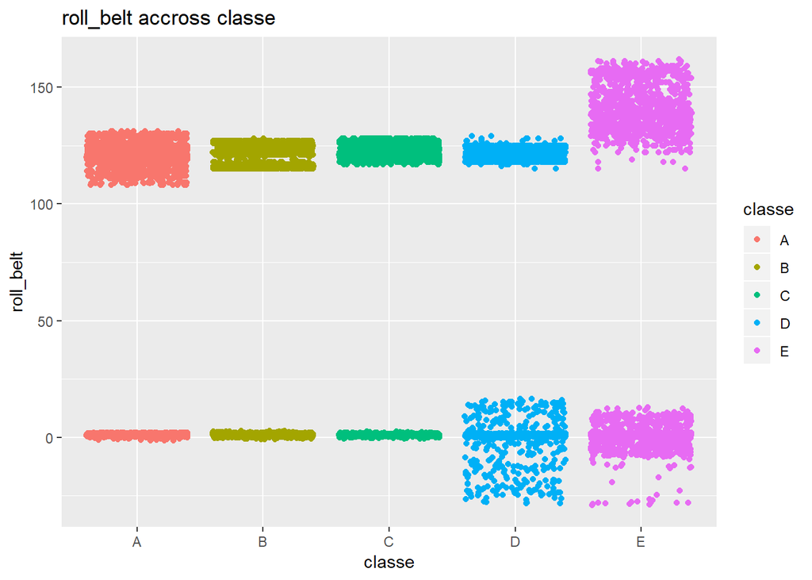

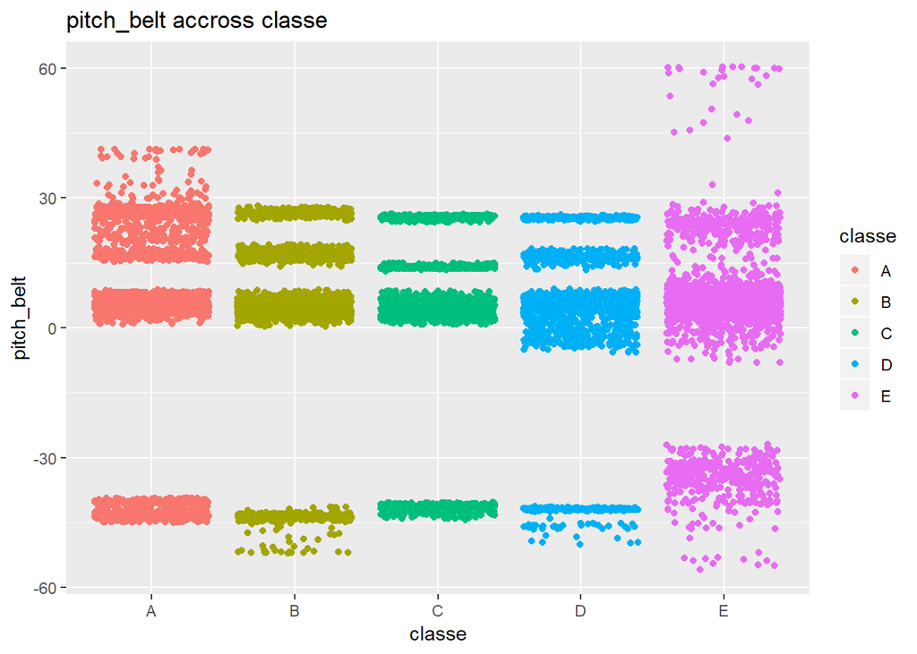

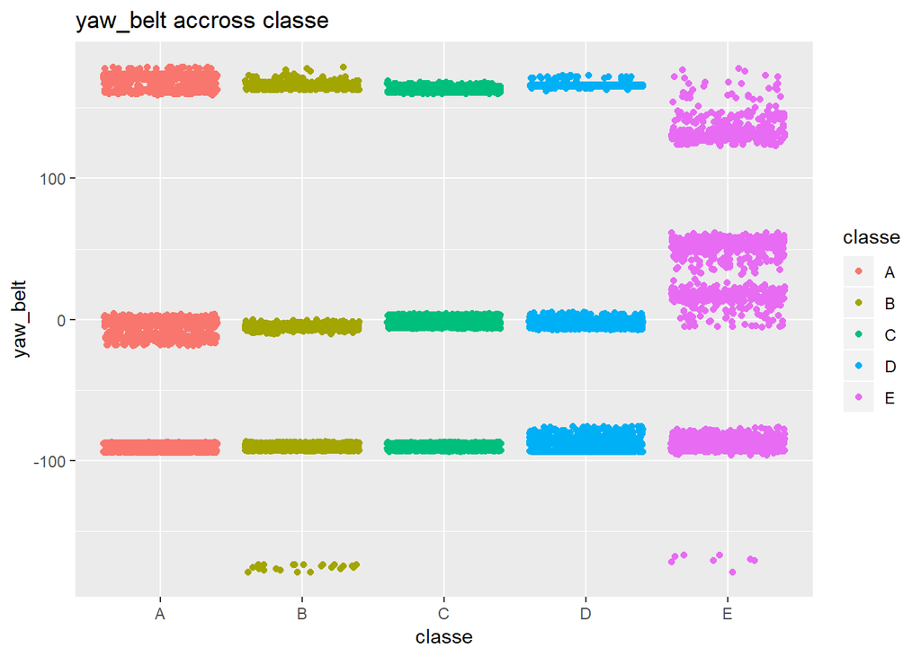

```r
for(i in 1:3) {
    varname <-  names(training_refined)[i]
    gg <- ggplot(training_refined,aes_string(x='classe',y=varname)) +
        geom_jitter(aes(col=classe)) + ggtitle(paste(varname,'accross classe'))
    print(gg)
}
```

It seems, at least from these first three plots, that each metric clusters around particular values accross all of the `classe` values. This is unhelpful. There is also a phenomenon however, whereby particular `classe` values are ascociated with a greater/smaller spread of the data around these particular values. This could be exploited by our model.

With only 52 variables, the choice was made to select predictors by eye, below the data is further refined to include only these variables and the `classe` variable.

```r
useful_vars <- c(1,2,3,4,5,6,7,8,9,10,11,12,13,16,17,19,21,22,23,24,27,28,30,31,32,33,34,35,36,37,38,39,40,41,42,43,44,45,46,48,49,50,51,52)
names(training_refined)[useful_vars]
```

```
##  [1] "roll_belt"            "pitch_belt"           "yaw_belt"
##  [4] "total_accel_belt"     "gyros_belt_x"         "gyros_belt_y"
##  [7] "gyros_belt_z"         "accel_belt_x"         "accel_belt_y"
## [10] "accel_belt_z"         "magnet_belt_x"        "magnet_belt_y"
## [13] "magnet_belt_z"        "yaw_arm"              "total_accel_arm"
## [16] "gyros_arm_y"          "accel_arm_x"          "accel_arm_y"
## [19] "accel_arm_z"          "magnet_arm_x"         "roll_dumbbell"
## [22] "pitch_dumbbell"       "total_accel_dumbbell" "gyros_dumbbell_x"
## [25] "gyros_dumbbell_y"     "gyros_dumbbell_z"     "accel_dumbbell_x"
## [28] "accel_dumbbell_y"     "accel_dumbbell_z"     "magnet_dumbbell_x"
## [31] "magnet_dumbbell_y"    "magnet_dumbbell_z"    "roll_forearm"
## [34] "pitch_forearm"        "yaw_forearm"          "total_accel_forearm"
## [37] "gyros_forearm_x"      "gyros_forearm_y"      "gyros_forearm_z"
## [40] "accel_forearm_y"      "accel_forearm_z"      "magnet_forearm_x"
## [43] "magnet_forearm_y"     "magnet_forearm_z"
```

```r
training_refined_2 <- select(training_refined,c(useful_vars,classe))
```

This leaves us with 44 predictors.

Now a second pre processing function that takes `training` and produces `training_refined_2` is created. This is important so that we can process the test and validation data the same way we processsed the training data.

```r
pre_process_2 <- function(DF) {
    select(DF[,-more_than_90_perc_missing],c(useful_vars,classe))
}

all(training_refined_2==pre_process_2(training))
```

```
## [1] TRUE
```

## Training

Now we train models, from the above plots it would appear that the data don’t follow any identifiable common distribution, so model based approaches are not favourable. It also seems the data do not have a linear effect on `classe`. Methods cutting the 44 dimensional space of variables might prove fruitful, since there are some variables that can predict classes if their value is over/under a certain threshold. See the figure below for a demonstration of this idea.

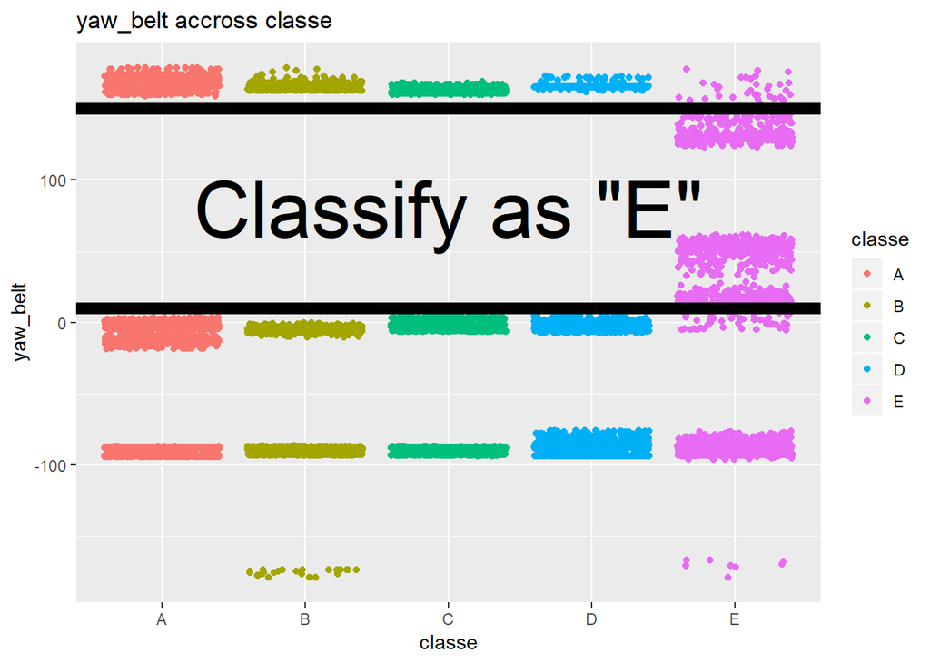

Three methods were chosen, random forrests, k nearest neighbours (knn) and classification trees.

The Knn method would benefit from scaling the data since it assumes that the `classe` variable is constant in a local neighbourhood of the data space. By scaling the data we can avoid weighting variables based on the scale of their measurements, which would be misguided.

```r
mod_knn <- train(classe ~ . ,data=training_refined_2,method='knn',tuneGrid=data.frame(k=1:3),preProcess=c('center','scale'))
```

For the classification tree the `rpart` package is used, the complexity parameter, `cp` must be tuned to optimise the complexity of the resulting tree.

```r
mod_rpart <- train(classe ~ . ,data=training_refined_2,method='rpart',tuneGrid=data.frame(cp=seq(0.00000001,0.0001,0.00001)),trControl=trainControl(method='cv',number=25))
```

Finally a random forrest is fit, the optimal tuning parameter `mtry` is found by default in this case, without need to pass `train` a `tuneGrid` argument.

```r
mod_rf <- train(classe ~ . ,data=training_refined_2,method='rf')
```

## Testing

Each model is now tested on the `testing` data set to estimate the out of sample error. The best performer will be selected as the final solution.

```r
modList <- list(mod_knn=mod_knn,mod_rpart=mod_rpart,mod_rf=mod_rf)

testing <- testing %>% pre_process_1 %>% pre_process_2


predictions <- lapply(modList,function(mod) {predict(mod,testing)})
conf_mats <- lapply(predictions,function(pred) {confusionMatrix(pred,testing$classe)})

print(conf_mats$mod_knn)
```

```
## Confusion Matrix and Statistics
##
##           Reference
## Prediction    A    B    C    D    E
##          A 1104    4    0    0    0
##          B    8  750    5    0    8
##          C    3    4  667   10    1
##          D    1    0   11  632    2
##          E    0    1    1    1  710
##
## Overall Statistics
##
##                Accuracy : 0.9847
##                  95% CI : (0.9804, 0.9883)
##     No Information Rate : 0.2845
##     P-Value [Acc > NIR] : < 2.2e-16
##
##                   Kappa : 0.9807
##  Mcnemar's Test P-Value : NA
##
## Statistics by Class:
##
##                      Class: A Class: B Class: C Class: D Class: E
## Sensitivity            0.9892   0.9881   0.9751   0.9829   0.9847
## Specificity            0.9986   0.9934   0.9944   0.9957   0.9991
## Pos Pred Value         0.9964   0.9728   0.9737   0.9783   0.9958
## Neg Pred Value         0.9957   0.9971   0.9947   0.9966   0.9966
## Prevalence             0.2845   0.1935   0.1744   0.1639   0.1838
## Detection Rate         0.2814   0.1912   0.1700   0.1611   0.1810
## Detection Prevalence   0.2824   0.1965   0.1746   0.1647   0.1817
## Balanced Accuracy      0.9939   0.9908   0.9848   0.9893   0.9919
```

```r
print(conf_mats$mod_rpart)
```

```
## Confusion Matrix and Statistics
##
##           Reference
## Prediction    A    B    C    D    E
##          A 1074   21    6    5    4
##          B   25  674   25   13   14
##          C    5   41  620   20    6
##          D    8    9   22  593   15
##          E    4   14   11   12  682
##
## Overall Statistics
##
##                Accuracy : 0.9286
##                  95% CI : (0.9201, 0.9365)
##     No Information Rate : 0.2845
##     P-Value [Acc > NIR] : <2e-16
##
##                   Kappa : 0.9097
##  Mcnemar's Test P-Value : 0.6643
##
## Statistics by Class:
##
##                      Class: A Class: B Class: C Class: D Class: E
## Sensitivity            0.9624   0.8880   0.9064   0.9222   0.9459
## Specificity            0.9872   0.9757   0.9778   0.9835   0.9872
## Pos Pred Value         0.9676   0.8975   0.8960   0.9165   0.9433
## Neg Pred Value         0.9851   0.9732   0.9802   0.9847   0.9878
## Prevalence             0.2845   0.1935   0.1744   0.1639   0.1838
## Detection Rate         0.2738   0.1718   0.1580   0.1512   0.1738
## Detection Prevalence   0.2829   0.1914   0.1764   0.1649   0.1843
## Balanced Accuracy      0.9748   0.9318   0.9421   0.9529   0.9666
```

```r
print(conf_mats$mod_rf)
```

```
## Confusion Matrix and Statistics
##
##           Reference
## Prediction    A    B    C    D    E
##          A 1115   11    0    0    0
##          B    1  745    3    0    1
##          C    0    3  678    9    1
##          D    0    0    3  634    3
##          E    0    0    0    0  716
##
## Overall Statistics
##
##                Accuracy : 0.9911
##                  95% CI : (0.9876, 0.9938)
##     No Information Rate : 0.2845
##     P-Value [Acc > NIR] : < 2.2e-16
##
##                   Kappa : 0.9887
##  Mcnemar's Test P-Value : NA
##
## Statistics by Class:
##
##                      Class: A Class: B Class: C Class: D Class: E
## Sensitivity            0.9991   0.9816   0.9912   0.9860   0.9931
## Specificity            0.9961   0.9984   0.9960   0.9982   1.0000
## Pos Pred Value         0.9902   0.9933   0.9812   0.9906   1.0000
## Neg Pred Value         0.9996   0.9956   0.9981   0.9973   0.9984
## Prevalence             0.2845   0.1935   0.1744   0.1639   0.1838
## Detection Rate         0.2842   0.1899   0.1728   0.1616   0.1825
## Detection Prevalence   0.2870   0.1912   0.1761   0.1631   0.1825
## Balanced Accuracy      0.9976   0.9900   0.9936   0.9921   0.9965
```

It can be seen that `mod_rf` outperfomed the other models, this will be the resulting solution to the problem.

## Validation

Because the error on the test set decided our choice of model, we have effectively trained our model on the testing dataset. Finally `mod_rf` is run on `validation` to accurately estimate out of sample error.

```r
validation <- validation %>% pre_process_1 %>% pre_process_2
confusionMatrix(predict(mod_rf,validation),validation$classe)
```

```
## Confusion Matrix and Statistics
##
##           Reference
## Prediction    A    B    C    D    E
##          A 1111    6    0    0    0
##          B    2  749    0    1    0
##          C    2    4  681   11    1
##          D    0    0    3  631    2
##          E    1    0    0    0  718
##
## Overall Statistics
##
##                Accuracy : 0.9916
##                  95% CI : (0.9882, 0.9942)
##     No Information Rate : 0.2845
##     P-Value [Acc > NIR] : < 2.2e-16
##
##                   Kappa : 0.9894
##  Mcnemar's Test P-Value : NA
##
## Statistics by Class:
##
##                      Class: A Class: B Class: C Class: D Class: E
## Sensitivity            0.9955   0.9868   0.9956   0.9813   0.9958
## Specificity            0.9979   0.9991   0.9944   0.9985   0.9997
## Pos Pred Value         0.9946   0.9960   0.9742   0.9921   0.9986
## Neg Pred Value         0.9982   0.9968   0.9991   0.9963   0.9991
## Prevalence             0.2845   0.1935   0.1744   0.1639   0.1838
## Detection Rate         0.2832   0.1909   0.1736   0.1608   0.1830
## Detection Prevalence   0.2847   0.1917   0.1782   0.1621   0.1833
## Balanced Accuracy      0.9967   0.9929   0.9950   0.9899   0.9978
```

Accuracy is estimated to be between 98.82% and 99.42% with 95% confidence. This is an acceptable solution.

## Appendix

```r
str(training)
```

```
## 'data.frame':    11776 obs. of  153 variables:
##  $ roll_belt               : num  1.41 1.48 1.42 1.42 1.43 1.45 1.45 1.43 1.42 1.51 ...
##  $ pitch_belt              : num  8.07 8.07 8.09 8.13 8.16 8.17 8.18 8.18 8.2 8.12 ...
##  $ yaw_belt                : num  -94.4 -94.4 -94.4 -94.4 -94.4 -94.4 -94.4 -94.4 -94.4 -94.4 ...
##  $ total_accel_belt        : int  3 3 3 3 3 3 3 3 3 3 ...
##  $ kurtosis_roll_belt      : num  NA NA NA NA NA NA NA NA NA NA ...
##  $ kurtosis_picth_belt     : num  NA NA NA NA NA NA NA NA NA NA ...
##  $ kurtosis_yaw_belt       : num  NA NA NA NA NA NA NA NA NA NA ...
##  $ skewness_roll_belt      : num  NA NA NA NA NA NA NA NA NA NA ...
##  $ skewness_roll_belt.1    : num  NA NA NA NA NA NA NA NA NA NA ...
##  $ skewness_yaw_belt       : num  NA NA NA NA NA NA NA NA NA NA ...
##  $ max_roll_belt           : num  NA NA NA NA NA NA NA NA NA NA ...
##  $ max_picth_belt          : int  NA NA NA NA NA NA NA NA NA NA ...
##  $ max_yaw_belt            : num  NA NA NA NA NA NA NA NA NA NA ...
##  $ min_roll_belt           : num  NA NA NA NA NA NA NA NA NA NA ...
```

[output cut: 86 more lines]